# 5.Dimensionality reduction techniques

#### PCA

First I will perform principal component analysis (PCA) on the not standardized human data.

```r
pca_human <- prcomp(human)
```

```r
# creating and print out a summary of pca_human_std
s1 <- summary(pca_human)
s1
```

```
## Importance of components:
##                              PC1      PC2   PC3   PC4   PC5   PC6    PC7    PC8
## Standard deviation     1.854e+04 185.5219 25.19 11.45 3.766 1.566 0.1912 0.1591
## Proportion of Variance 9.999e-01   0.0001  0.00  0.00 0.000 0.000 0.0000 0.0000
## Cumulative Proportion  9.999e-01   1.0000  1.00  1.00 1.000 1.000 1.0000 1.0000
```

```r
# getting rounded percetanges of variance captured by each PC
pca_pr1 <- round(100*s1$importance[2, ], digits = 1)
pca_pr1
```

```
## PC1 PC2 PC3 PC4 PC5 PC6 PC7 PC8
## 100   0   0   0   0   0   0   0
```

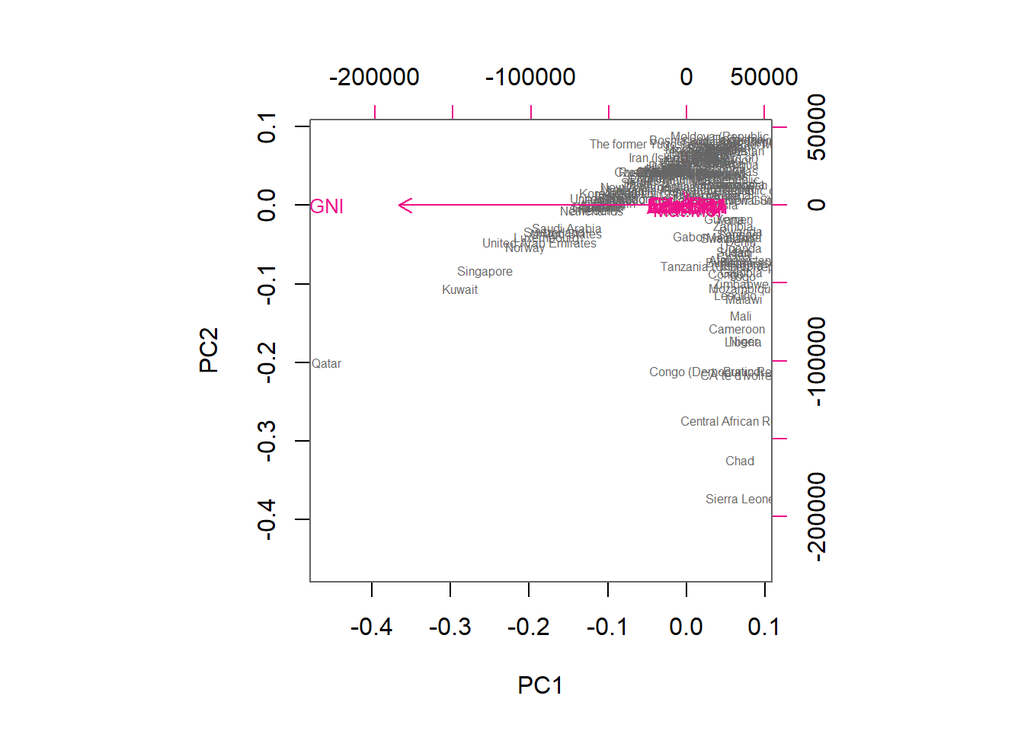

```r
biplot(pca_human, choices = 1:2, cex = c(0.5, 0.8), col = c("grey40", "deeppink2"))
```

From the summary of rounded percetanges of variance, we can see that PC1 explains 100 % of the variance and others are 0. So now it seems like Gross National Income per capita (GNI) is the only variable explaining the variance, and it is pointing in the same direction as PC1 so it is contributing that dimension.

Next I will standardize the variables and repeat the above analysis.

```r
human_std <- scale(human)
summary(human_std)
```

```
##     Edu2.FM           Labo.FM           Edu.Exp           Life.Exp
##  Min.   :-2.8189   Min.   :-2.6247   Min.   :-2.7378   Min.   :-2.7188
##  1st Qu.:-0.5233   1st Qu.:-0.5484   1st Qu.:-0.6782   1st Qu.:-0.6425
##  Median : 0.3503   Median : 0.2316   Median : 0.1140   Median : 0.3056
##  Mean   : 0.0000   Mean   : 0.0000   Mean   : 0.0000   Mean   : 0.0000
##  3rd Qu.: 0.5958   3rd Qu.: 0.7350   3rd Qu.: 0.7126   3rd Qu.: 0.6717
##  Max.   : 2.6646   Max.   : 1.6632   Max.   : 2.4730   Max.   : 1.4218
##       GNI             Mat.Mor          Ado.Birth          Parli.F
##  Min.   :-0.9193   Min.   :-0.6992   Min.   :-1.1325   Min.   :-1.8203
##  1st Qu.:-0.7243   1st Qu.:-0.6496   1st Qu.:-0.8394   1st Qu.:-0.7409
##  Median :-0.3013   Median :-0.4726   Median :-0.3298   Median :-0.1403
##  Mean   : 0.0000   Mean   : 0.0000   Mean   : 0.0000   Mean   : 0.0000
##  3rd Qu.: 0.3712   3rd Qu.: 0.1932   3rd Qu.: 0.6030   3rd Qu.: 0.6127
##  Max.   : 5.6890   Max.   : 4.4899   Max.   : 3.8344   Max.   : 3.1850
```

```r
pca_human_std <- prcomp(human_std)
```

```r
# creating and print out a summary of pca_human_std
s2 <- summary(pca_human_std)
s2
```

```
## Importance of components:
##                           PC1    PC2     PC3     PC4     PC5     PC6     PC7
## Standard deviation     2.0708 1.1397 0.87505 0.77886 0.66196 0.53631 0.45900
## Proportion of Variance 0.5361 0.1624 0.09571 0.07583 0.05477 0.03595 0.02634
## Cumulative Proportion  0.5361 0.6984 0.79413 0.86996 0.92473 0.96069 0.98702
##                            PC8
## Standard deviation     0.32224
## Proportion of Variance 0.01298
## Cumulative Proportion  1.00000
```

```r
# getting rounded percetanges of variance captured by each PC
pca_pr <- round(100*s2$importance[2, ], digits = 1)
pca_pr
```

```
##  PC1  PC2  PC3  PC4  PC5  PC6  PC7  PC8
## 53.6 16.2  9.6  7.6  5.5  3.6  2.6  1.3
```

```r
# creating object pc_lab to be used as axis labels so that we can see the percentages of PCs
pc_lab <- paste0(names(pca_pr), " (", pca_pr, "%)")
```

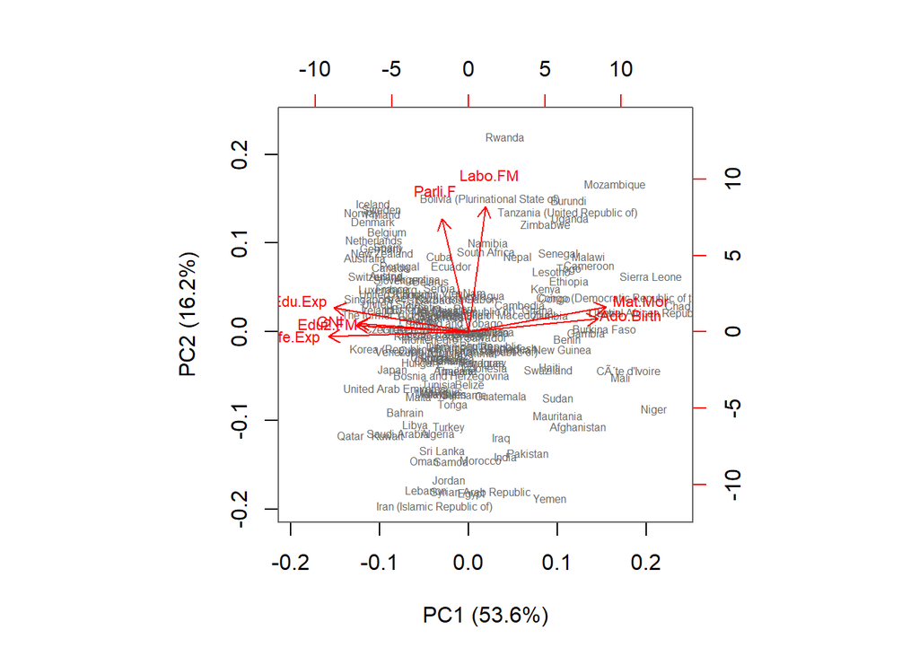

```r
biplot(pca_human_std, cex = c(0.5, 0.7), col = c("grey40", "red"), xlab = pc_lab[1], ylab = pc_lab[2])
```

If we compare non-standardized and standardized PCA-plots, they look totally different. Now there are multiple arrows pointing at different directions. PC1 explains 53.6 % of the variance and PC2 16.2 %. Small angle between arrows means high positive correlation, so there is high positive correlation between variables Maternal mortality ratio (Mat.Mor) and Adolescent birth rate (Ado.Birth) which was seen also earlier in the correlation plot. They have also small angle between PC1 which means also high positive correlation between them and they are contributing that dimension. There are multiple arrows pointing at the opposite direction from (Mat.Mor) and (Ado.Birth). They are also affecting PC1 and correlating with it. There are also very small angles between all of them so they are correlating with each other. Those variables are: Expected years of schooling (Edu.exp), Proportion of females versus males with at least secondary education (Edu2.FM), Life expectancy at birth (Life.Exp) and Gross National Income per capita (GNI). GNI arrow is still pointing in the same direction as in the non-standardized PCA-plot. There are still two variables Proportion of females versus males in the labour force (Labo.FM) and Percetange of female representatives in parliament (Parli.F) which are pointing upwards, in the same direction as PC2 so they are correlating with it. There is clear angle between them, so the correlation between those variables is smaller but still existing. But angles between the arrows pointing up versus others pointing horizontally are quite big, which means that there is no correlation between them. Almost all the lenghts of the arrows are equal, which means that the standard deviations are quite equal.

I think the first two PC dimensions explain well the distributions of different countries based on different variables. If we look at the standardized human data PCA plot, we can see that in the right side, there are a lot of African countries, whereas on the left side there are Westerns countries and the Nordic countries in the left upper corner. And also in the bottom of the plot are mainly Arabic countries. We all know that there are differences between those countries which are also shown in this plot. For example in the African countries Maternal mortality ratio (Mat.Mor) and Adolescent birth rate (Ado.Birth) are higher, in the Western countries Expected years of schooling (Edu.exp), Proportion of females versus males with at least secondary education (Edu2.FM), Life expectancy at birth (Life.Exp) and Gross National Income per capita (GNI) are higher and also in the Nordic countries the Percentage of female representatives in parliament (Parli.F) is higher as we know from Finland for example. Whereas in some of the Arabic countries the situation is opposite considering the Percentage of female representatives in parliament. But there are also exceptions like Rwanda in the up.

#### Tea dataset and MCA analysis

```r
library(FactoMineR)
```

In this last part of exercise 5, I will explore the dataset Tea from FactoMineR-library. Then I will perform Multiple Correspondence Analysis on the data.

```r
data(tea)
str(tea)
```

```
## 'data.frame':    300 obs. of  36 variables:
##  $ breakfast       : Factor w/ 2 levels "breakfast","Not.breakfast": 1 1 2 2 1 2 1 2 1 1 ...
##  $ tea.time        : Factor w/ 2 levels "Not.tea time",..: 1 1 2 1 1 1 2 2 2 1 ...
##  $ evening         : Factor w/ 2 levels "evening","Not.evening": 2 2 1 2 1 2 2 1 2 1 ...
##  $ lunch           : Factor w/ 2 levels "lunch","Not.lunch": 2 2 2 2 2 2 2 2 2 2 ...
##  $ dinner          : Factor w/ 2 levels "dinner","Not.dinner": 2 2 1 1 2 1 2 2 2 2 ...
##  $ always          : Factor w/ 2 levels "always","Not.always": 2 2 2 2 1 2 2 2 2 2 ...
##  $ home            : Factor w/ 2 levels "home","Not.home": 1 1 1 1 1 1 1 1 1 1 ...
##  $ work            : Factor w/ 2 levels "Not.work","work": 1 1 2 1 1 1 1 1 1 1 ...
##  $ tearoom         : Factor w/ 2 levels "Not.tearoom",..: 1 1 1 1 1 1 1 1 1 2 ...
##  $ friends         : Factor w/ 2 levels "friends","Not.friends": 2 2 1 2 2 2 1 2 2 2 ...
##  $ resto           : Factor w/ 2 levels "Not.resto","resto": 1 1 2 1 1 1 1 1 1 1 ...
##  $ pub             : Factor w/ 2 levels "Not.pub","pub": 1 1 1 1 1 1 1 1 1 1 ...
##  $ Tea             : Factor w/ 3 levels "black","Earl Grey",..: 1 1 2 2 2 2 2 1 2 1 ...
##  $ How             : Factor w/ 4 levels "alone","lemon",..: 1 3 1 1 1 1 1 3 3 1 ...
```

[output cut: 22 more lines]

```r
dim(tea)#300 rows and 36 columns
```

```
## [1] 300  36
```

There are 300 observations of 36 variables in the tea data. Data has variables that consider when, where and how people drink tea and different kind of experiences related to drinking tea.

#### Graphical overview

Here are the bar plots of all the variables. They are shown in multiple pictures, because that way they are easier to read

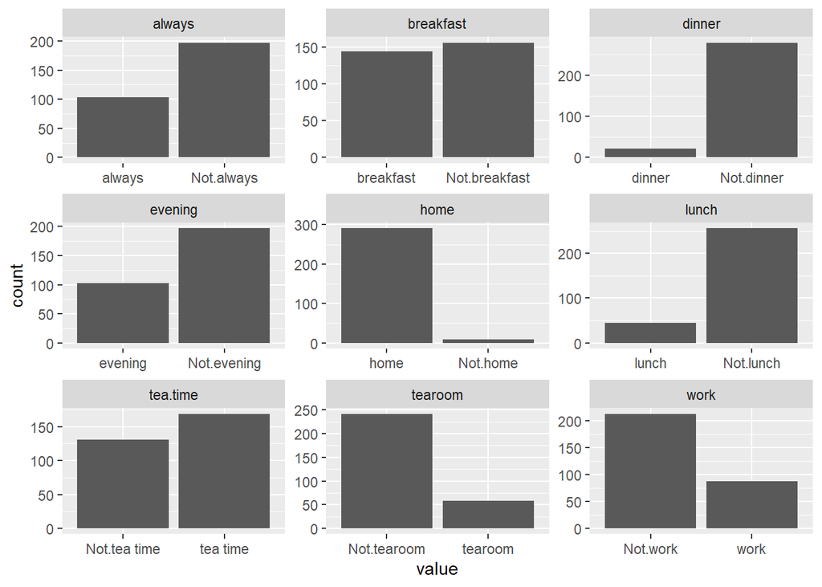

```r
gather(tea[1:9]) %>% ggplot(aes(value)) + facet_wrap("key", scales = "free") + geom_bar()
```

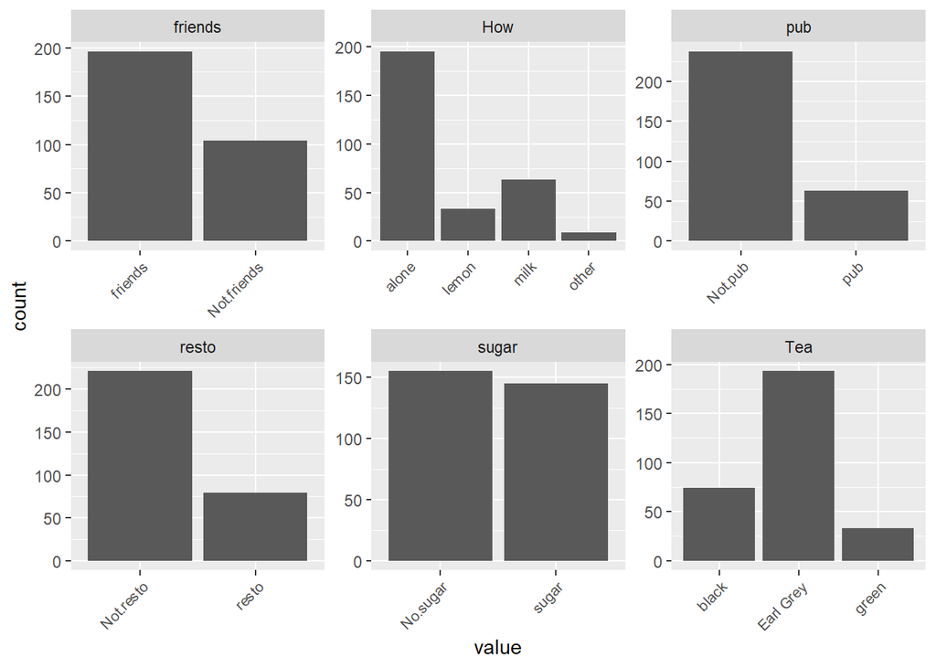

```r
gather(tea[10:15]) %>% ggplot(aes(value)) + facet_wrap("key", scales = "free") + geom_bar() +theme(axis.text.x = element_text(angle = 45, hjust = 1, size = 8))
```

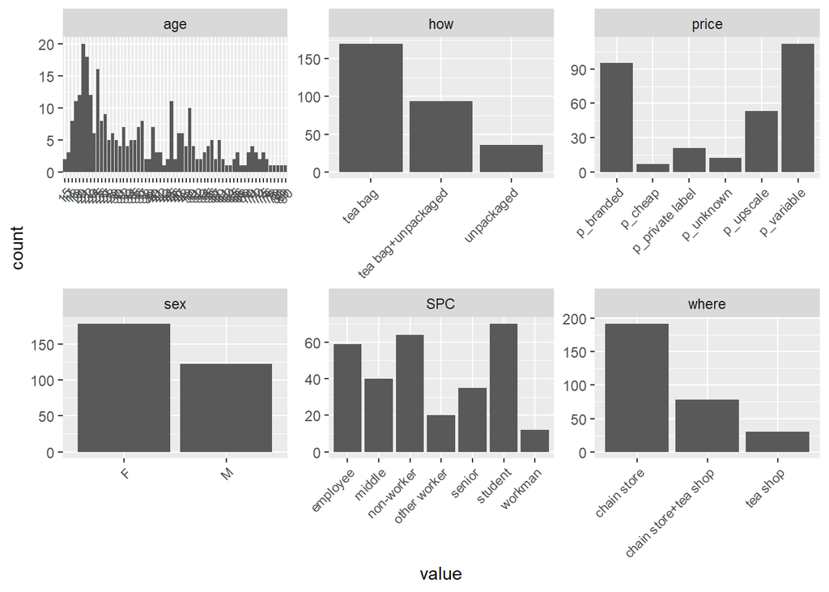

```r
gather(tea[16:21]) %>% ggplot(aes(value)) + facet_wrap("key", scales = "free") + geom_bar() +theme(axis.text.x = element_text(angle = 45, hjust = 1, size = 8))
```

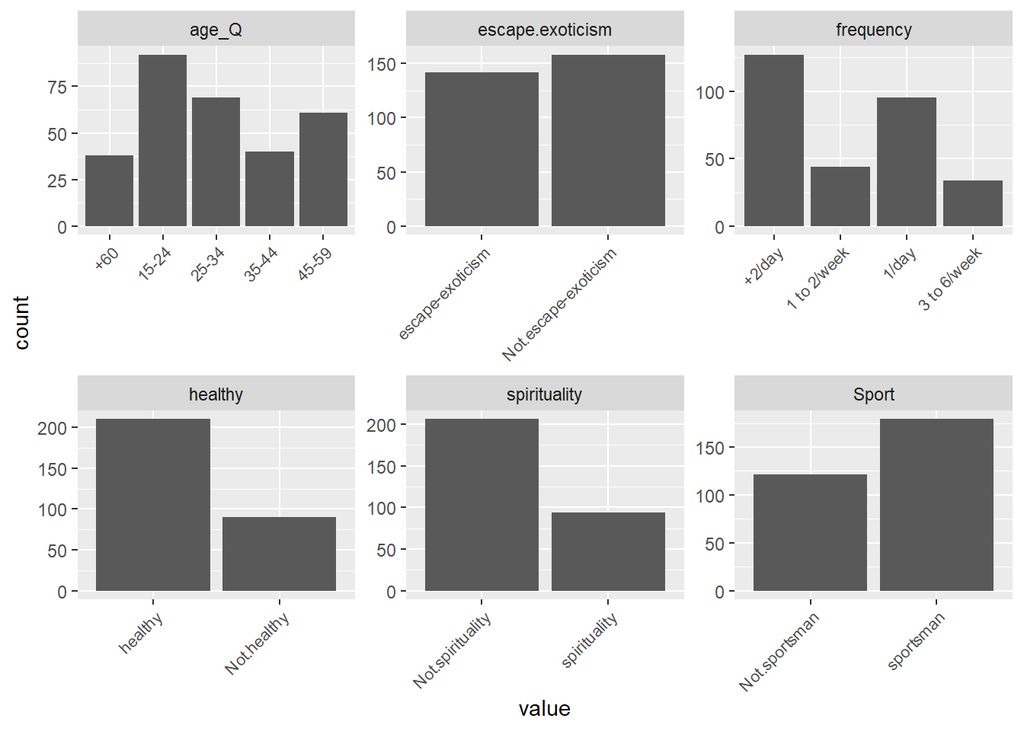

```r
gather(tea[22:27]) %>% ggplot(aes(value)) + facet_wrap("key", scales = "free") + geom_bar() +theme(axis.text.x = element_text(angle = 45, hjust = 1, size = 8))
```

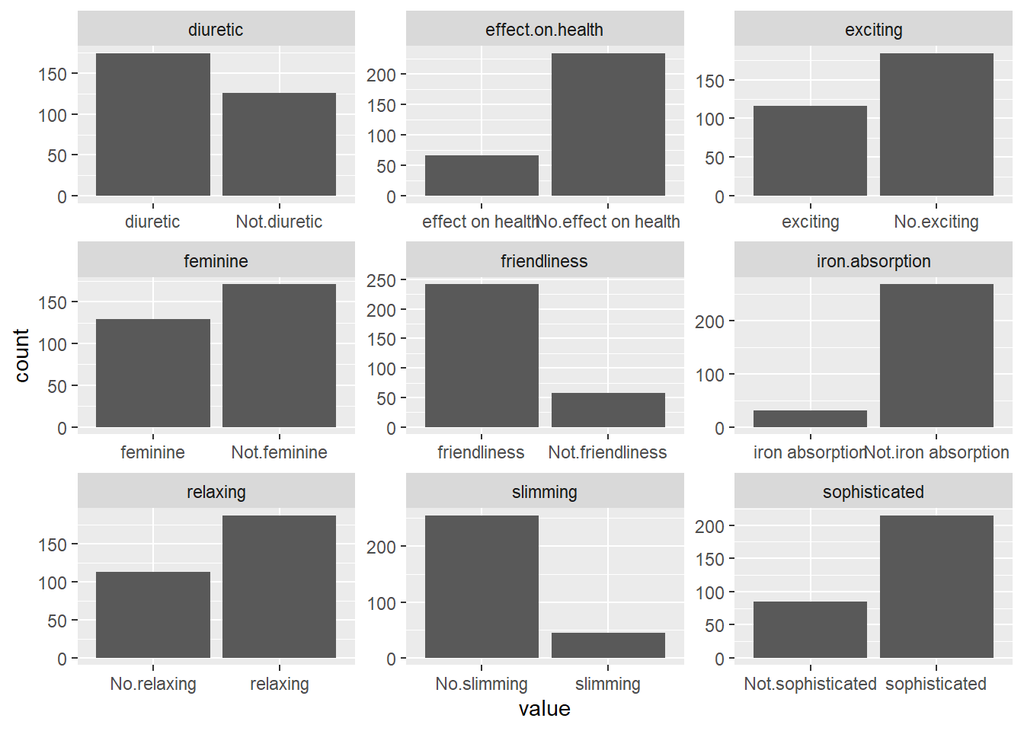

```r
gather(tea[28:36]) %>% ggplot(aes(value)) + facet_wrap("key", scales = "free") + geom_bar()
```

I chose variables Tea, How, sex, sugar, frequency, age_Q and effect.on.health for the MCA analysis.

```r
# column names to keep in the dataset
keep_columns <- c("Tea", "How", "sex", "sugar", "frequency", "age_Q", "effect.on.health")
```

```r
# select the 'keep_columns' to create a new dataset
tea_time <- dplyr::select(tea, one_of(keep_columns))
summary(tea_time)
```

```
##         Tea         How      sex          sugar           frequency
##  black    : 74   alone:195   F:178   No.sugar:155   1/day      : 95
##  Earl Grey:193   lemon: 33   M:122   sugar   :145   1 to 2/week: 44
##  green    : 33   milk : 63                          +2/day     :127
##                  other:  9                          3 to 6/week: 34
##
##    age_Q               effect.on.health
##  15-24:92   effect on health   : 66
##  25-34:69   No.effect on health:234
##  35-44:40
##  45-59:61
##  +60  :38
```

```r
str(tea_time)
```

```
## 'data.frame':    300 obs. of  7 variables:
##  $ Tea             : Factor w/ 3 levels "black","Earl Grey",..: 1 1 2 2 2 2 2 1 2 1 ...
##  $ How             : Factor w/ 4 levels "alone","lemon",..: 1 3 1 1 1 1 1 3 3 1 ...
##  $ sex             : Factor w/ 2 levels "F","M": 2 1 1 2 2 2 2 1 2 2 ...
##  $ sugar           : Factor w/ 2 levels "No.sugar","sugar": 2 1 1 2 1 1 1 1 1 1 ...
##  $ frequency       : Factor w/ 4 levels "1/day","1 to 2/week",..: 1 1 3 1 3 1 4 2 3 3 ...
##  $ age_Q           : Factor w/ 5 levels "15-24","25-34",..: 3 4 4 1 4 1 3 3 3 3 ...
##  $ effect.on.health: Factor w/ 2 levels "effect on health",..: 2 2 2 2 2 2 2 2 2 2 ...
```

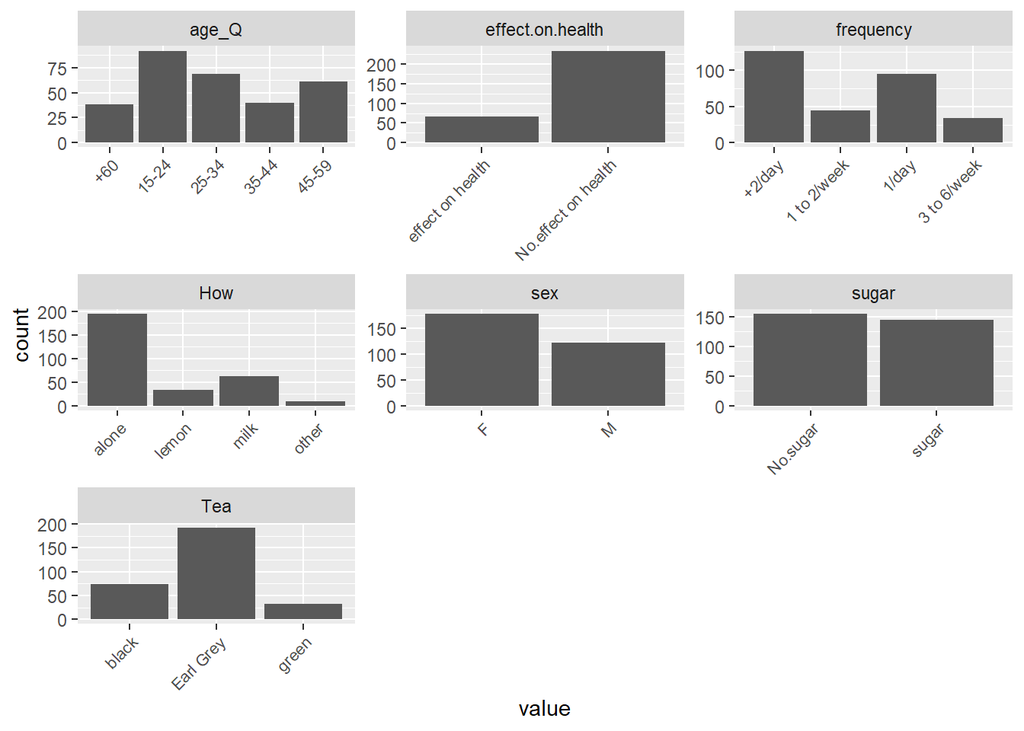

```r
gather(tea_time) %>% ggplot(aes(value)) + facet_wrap("key", scales = "free") + geom_bar() +theme(axis.text.x = element_text(angle = 45, hjust = 1, size = 8))
```

```r
mca <- MCA(tea_time, graph = FALSE)
summary(mca)
```

```
##
## Call:
## MCA(X = tea_time, graph = FALSE)
##
##
## Eigenvalues
##                        Dim.1   Dim.2   Dim.3   Dim.4   Dim.5   Dim.6   Dim.7
## Variance               0.242   0.210   0.184   0.170   0.159   0.154   0.149
## % of var.             11.286   9.818   8.592   7.943   7.417   7.170   6.952
## Cumulative % of var.  11.286  21.103  29.696  37.639  45.056  52.226  59.178
##                        Dim.8   Dim.9  Dim.10  Dim.11  Dim.12  Dim.13  Dim.14
## Variance               0.134   0.130   0.126   0.123   0.109   0.090   0.083
## % of var.              6.243   6.076   5.893   5.738   5.104   4.222   3.893
## Cumulative % of var.  65.421  71.497  77.391  83.128  88.232  92.455  96.348
##                       Dim.15
## Variance               0.078
## % of var.              3.652
## Cumulative % of var. 100.000
##
## Individuals (the 10 first)
##              Dim.1    ctr   cos2    Dim.2    ctr   cos2    Dim.3    ctr   cos2
## 1         |  0.016  0.000  0.000 |  0.546  0.473  0.139 |  0.155  0.044  0.011
## 2         |  0.706  0.688  0.236 |  0.271  0.116  0.035 | -0.499  0.450  0.118
## 3         |  0.490  0.331  0.203 | -0.573  0.520  0.277 | -0.450  0.366  0.171
## 4         | -0.669  0.618  0.377 | -0.114  0.021  0.011 | -0.024  0.001  0.000
## 5         |  0.301  0.125  0.070 | -0.146  0.034  0.016 | -0.476  0.410  0.175
## 6         | -0.280  0.108  0.067 | -0.186  0.055  0.030 | -0.261  0.123  0.058
## 7         |  0.113  0.018  0.005 |  0.042  0.003  0.001 |  0.112  0.023  0.005
## 8         |  0.508  0.356  0.086 |  0.303  0.145  0.030 |  0.371  0.249  0.046
## 9         |  0.248  0.085  0.029 |  0.203  0.065  0.019 | -0.010  0.000  0.000
## 10        |  0.617  0.526  0.189 |  0.233  0.086  0.027 |  0.142  0.036  0.010
##
## 1         |
## 2         |
## 3         |
## 4         |
## 5         |
## 6         |
## 7         |
## 8         |
```

[output cut: 21 more lines]

```
## milk       -0.158   0.407   0.007  -1.408 |
## other       2.464  14.128   0.188   7.492 |
## F           0.032   0.048   0.002   0.671 |
## M          -0.047   0.069   0.002  -0.671 |
## No.sugar   -0.344   4.735   0.126  -6.144 |
##
## Categorical variables (eta2)
##                    Dim.1 Dim.2 Dim.3
## Tea              | 0.342 0.220 0.264 |
## How              | 0.141 0.167 0.275 |
## sex              | 0.103 0.453 0.002 |
## sugar            | 0.448 0.013 0.126 |
## frequency        | 0.179 0.123 0.202 |
## age_Q            | 0.475 0.419 0.414 |
## effect.on.health | 0.005 0.076 0.006 |
```

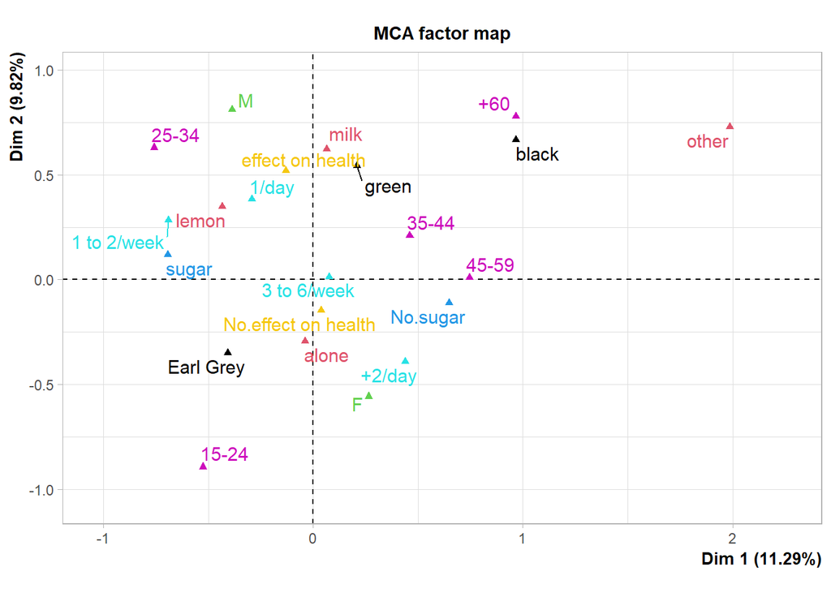

```r
plot(mca, invisible=c("ind"), habillage = "quali")
```

Here are some thoughts about the relationships between variables in tea data based on MCA factor map. Distances between variables in MCA plot tells about the similarity of the variables, closer they are to each other more similar they are. For example females (F) and males (M) are quite far away from each other so they are different. +60 and black are close to each other so maybe older people usually drink black tea. Green is also quite close to effect on health so maybe green tea has an effect on health compared to black tea for example. Age groups 35-44 and 45-59 are quite close to each other so maybe they have quite similar habits. Whereas 15-24 are far away from everything. Females (F) are close to +2/day, so maybe they drink tea more often. No sugar is closer to females and older people and sugar is closer to males and younger people so maybe this tells something about who uses sugar in their tea more often.